# Physics Validation of Y3 Clusters Code

Y3 Cluster Team (3ct)

2026-08-25

# 1 Introduction

This document presents demonstrations of the validity of calculations done in the Y3 clusters analysis code. Each section contains the validation testing results for a single function in our calculation.

1. For each of these functions, we have evaluations from a trusted source that are assumed to be correct. We test *our implementation* by comparing the results to the evaluations from the trusted source.
2. Unless otherwise indicated, we require fractional differences to be less than $10^{-6}$, **or** absolute differences less than $10^{-12}$. The relative error bound was chosen to be smaller than the systematic uncertainty to which the value is known from the trusted source. An absolute error bound is needed for the cases in which the predicted value is 0 or very close to 0.
3. In each section, we show both absolute and residual comparisons. In the absolute comparison plots, the *expected* (or *true*) values are shown in black, and results from our *implementation* (or *test* values) are shown in cyan. We also show the fractional (relative) and absolute residuals.
4. In the plot of the fractional residuals, the color of each point is determined by whether or not that point passes the absolute residual test. In the plot of the absolute residuals, the color of each point is determined by whether or not that point passes the fractional residual test. Thus, in each plot, a point passes the test if *either* it is blue or within the error bounds (indicated by horizontal lines). Points that fail the test will be both red and outside of the allowable error bounds (indicated by horizontal lines).
5. For a test to pass, it is required that every calculated point pass. This condition is verified automatically and the result is noted in bold in each section.

# 2 Part I — Costanzi-2026 pipeline (observable validation)

This part validates the **Costanzi-2026 pipeline sourced from `src/pipelines/`** end-to-end. The numbers behind every subsection come from the run pair

- `cosmosis-models/physics_validation_pipelines.ini` — cp_camb backend, dump `cosmosis-models/physics_validation_pipelines_output/`;
- `cosmosis-models/physics_validation_camb.ini` — CAMB-truth companion (same wall, same widePlanck fiducial), dump `cosmosis-models/physics_validation_camb_output/`;

in which **every observable stage is a `src/pipelines/` implementation**: `halo_model` = `src/pipelines/cosmology/halo_model.py`, `prj_params` and `sel_function` = `src/pipelines/systematics/{selection_function, selection_richness}`, `bsel` = `src/pipelines/systematics/selection_bias`, and the observables `NumCountsSijGl`, `NumCounts3d`, `Shear1hGl`, `ShearPrjGl`, `ShearPrjCuhre` = `src/pipelines/des_y3/{number_counts, shear_1h2h, shear_projection}`. The allowed non-pipelines inputs (owner decision, 2026-08-25) are **`MfTinker`** (CSL mass function), **`cp_camb`** (CosmoPower emulator), and the **survey-area/footprint** inputs; `consistency`/`GrowthFactor` are CosmoSIS bookkeeping. Two documented gaps remain sourced from the production tree because no `src/pipelines` equivalent exists yet: `average_sigma_crit_inv` (`src/modules/average_sigma_crit_inv/`) and the C++ `b_sel_marg` operator wall (`src/modules/b_sel_marg_cpu/BSelMargIntegrand.so`) that `bsel` closes. Both runs build $\xi_{\rm NL}$ from **linear** $P(k)$ (`docs/known_issues/xi_nl_linear_fallback.md`, issue #9): the CAMB companion deliberately sets `nonlinear = none` so the CAMB-vs-cp_camb residuals below are pure-emulator checks, not missing-halofit checks.

Algorithms and numerical recipes live in `docs/pipeline_modules.tex`; the source-tree catalog is in `docs/code_reference.md`. Each subsection compares one pipeline output against an independent reference (Python `richness_selection`, `cluster_toolkit`, or full CAMB).

*audit_data.R not found — headline numbers omitted; see `pipeline_modules.tex` §12.*

## 2.1 Linear matter power spectrum P(k, z) — `cp_camb`

CosmoPower emulator (`ytest`, read from `cdm_baryon_power_lin/p_k`) vs full CAMB at the same cosmology (`ytrue`). Comparison is on a 6 z × 25 k subsample restricted to the cluster lens-redshift range $z \in [0, 1]$. Headline: ≤0.7% across the prior box (see `docs/emulator_validation.tex`).

**150 of 150 points pass at frac < 0.007.**

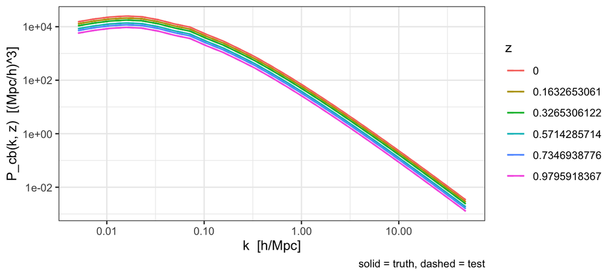

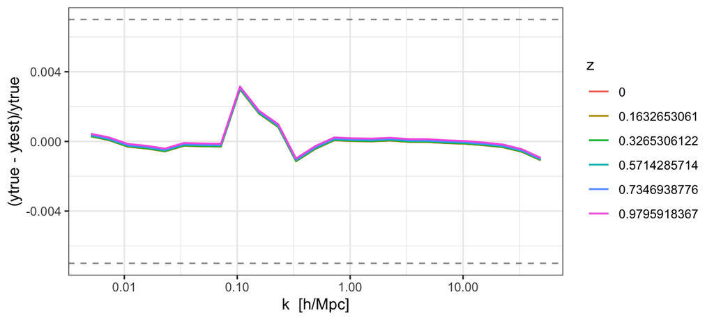

## 2.2 Halo mass function $n(M, z)$ — `mf_tinker`

CosmoSIS `MfTinker` driven by full CAMB (`ytrue`, read from `physics_validation_camb_output/mass_function/dndlnmh`) vs the same module driven by the cp_camb emulator (`ytest`, read from `physics_validation_pipelines_output/mass_function/dndlnmh`). Both use Tinker 2008 with $\Delta = 200m$ — apples-to-apples through the same HMF kernel; the only thing changing between truth and test is the upstream linear $P(k, z)$. Restricted to $M \in [10^{12}, 10^{15}] \,M_\odot/h$ and $z \le 1.0$.

**200 of 200 points pass at frac < 0.02.**

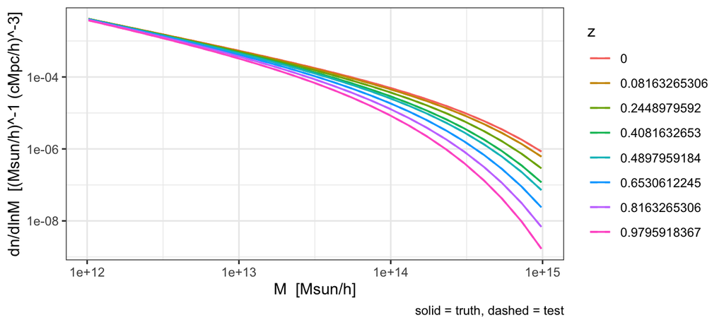

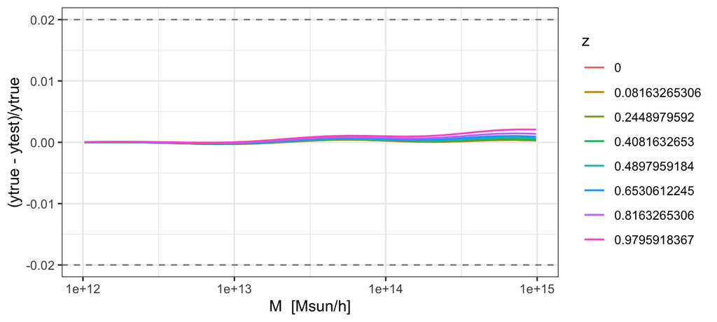

## 2.3 Halo bias $b(M, z)$ — `halo_model`

`halomodel/bias` published by `src/pipelines/cosmology/halo_model.py` (the pipelines halo-model module; verified bit-identical to the `y3_buzzard/halo_model_cosmosis.py` original on the same datablock) (`ytest`) vs **`cluster_toolkit.bias.bias_at_M`** (Tinker 2010) evaluated on the same widePlanck cosmology with the CAMB-driven `cdm_baryon_power_lin` $P(k, z)$ as input (`ytrue`). Δ = 200m, $M \in [10^{12}, 10^{15}]\,M_\odot/h$, $z \in [0, 1.0]$. The residual captures the full pipeline error: emulator $P(k)$, growth-factor normalisation fix (audit item 2), and CosmoSIS-vs-`cluster_toolkit` $\sigma(M)$ integrators.

**200 of 200 points pass at frac < 0.005.**

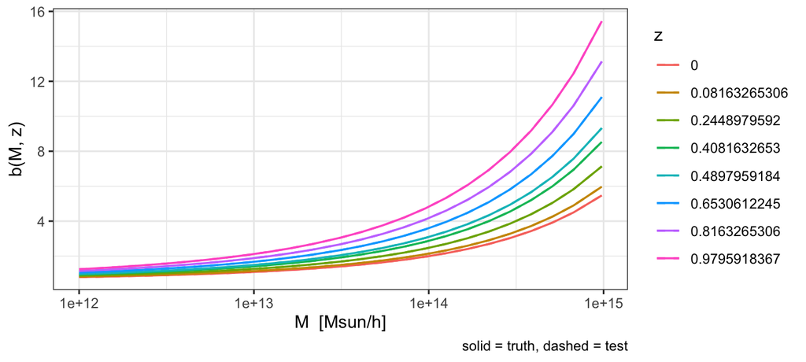

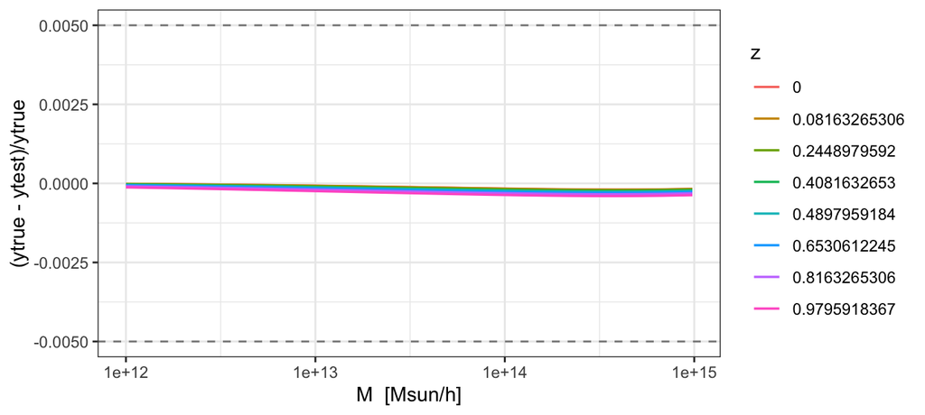

## 2.4 Number counts $N_i(\lambda, z)$ — `NumCounts3d`

### 2.4.1 Pure-emulator check: `NumCounts3d` (CAMB) vs `NumCounts3d` (cp_camb)

Both arms run the **same** brute-force adaptive triple integral `NumCounts3d` (`src/pipelines/des_y3/number_counts/cpp/3d`, the pipelines successor of `NumCountsFullScalarIntegrand`) over $(\ell^t, z, \ln M)$ at the same widePlanck cosmology; the only difference is the upstream linear $P(k)$. This mirrors `docs/emulator_validation.tex` Sec. 2 (the v3c emulator validation report), whose Table 1 reports per-bin residuals 0.23–0.69%.

**12 of 12 points pass at frac < 0.01.**

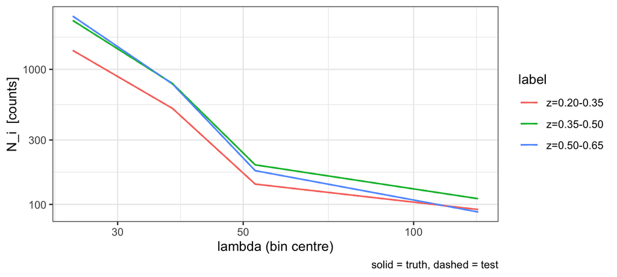

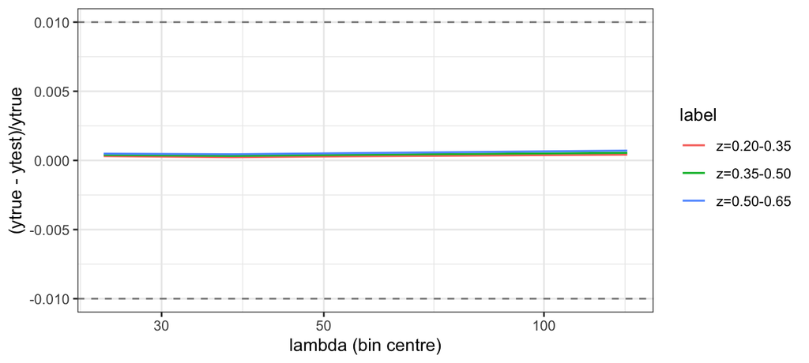

### 2.4.2 Production-path check: `NumCounts3d` (CAMB) vs `NumCountsSijGl` (cp_camb)

**12 of 12 points pass at frac < 0.05.**

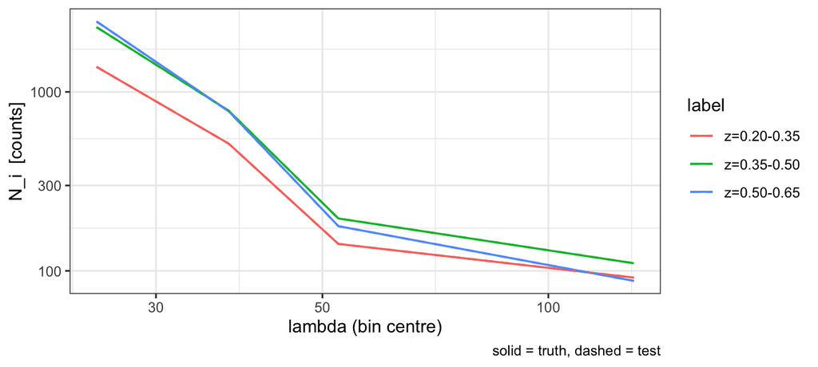

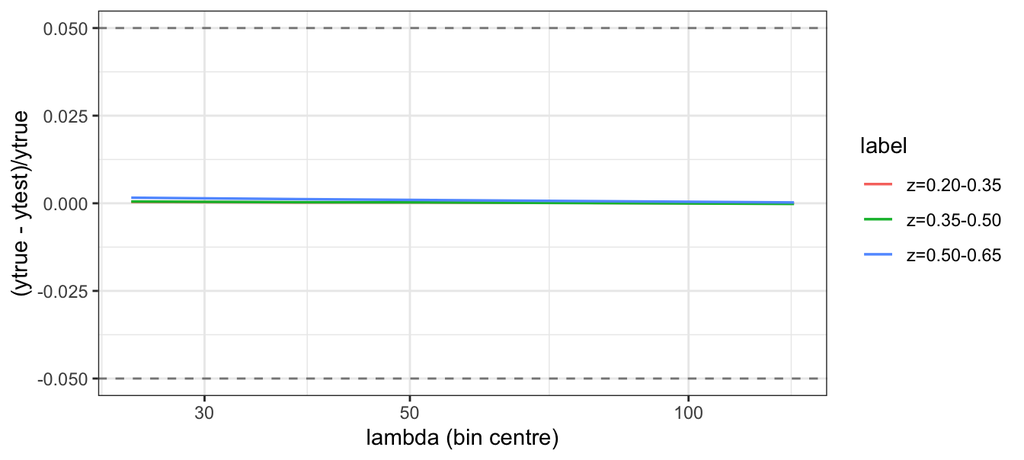

## 2.5 Mass- and bias-weighted $N_i$ — effective mass and bias

> *Validation script TBD.* MassWeightedSel and BiasWeightedSel against analytic M_eff = ⟨M⟩_S, b_eff = ⟨b⟩_S on the same 4×3 grid (no src/pipelines backend exists yet; modules would also need adding to physics_validation_pipelines.ini). See `emit_validation_tsv.py` stub for the implementation hook.

## 2.6 $(\mathcal{P}[1], I_1, J)$ — selection-bias operators from `b_sel_marg`

The three P[X] operator walls published by the C++ `b_sel_marg` module (`BSelMargIntegrand.so`, sections `b_sel_marg_{p1, i1, j}`; $J \equiv I_2 - I_1$ computed directly to avoid cancellation), compared against the Python `richness_selection.SelBias._P_operator` reference evaluated on the same datablock inputs (same HMF, halo bias, $\xi_{\rm NL}$, and the dump’s own `cluster_mor` HOD point). 12 wall rows $\times$ 3 operators = 36 cells.

**36 of 36 points pass at frac < 0.05.**

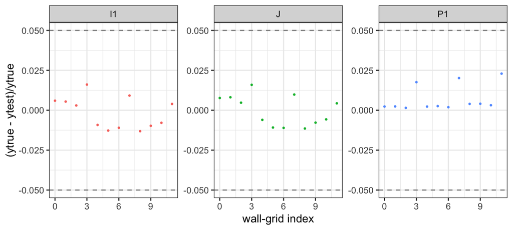

## 2.7 $\overline{b}^{\rm LOS}_{ij}, \overline{b}^{\rm LSS}_{ij}$ — sigmoid plateaus from `bsel`

The two latent-marginalised plateau amplitudes of the mixture-of-regimes ansatz [`projection_lensing_paper.tex` Eq.~b_sigmoid, Eq.~b_marg_lt] are published by the Python `bsel` finisher (`src/pipelines/systematics/selection_bias/python/bsel.py`) under the datablock keys `b_sel_marginalised/{b_small, b_large}`, with the mapping

- `b_small` $\leftrightarrow \overline{b}^{\rm LOS}_{ij}$ (small-$\theta$ / correlated-LOS asymptote),
- `b_large` $\leftrightarrow \overline{b}^{\rm LSS}_{ij}$ (large-$\theta$ / LSS asymptote).

- `ytest` — production path: per-$\lambda^o$ Gauss–Legendre on $\ell^t \in [1,\,3\lambda^o]$.
- `ytrue` — `scipy.integrate.quad` (`epsabs=1e-12, epsrel=1e-9`) over the same integrand on the same support.

**20 of 24 points pass at frac < 0.05.**

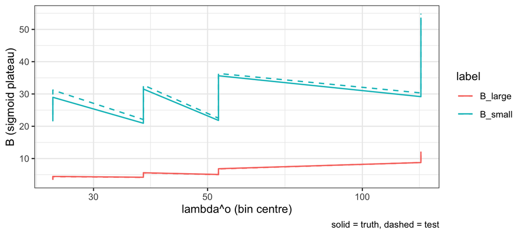

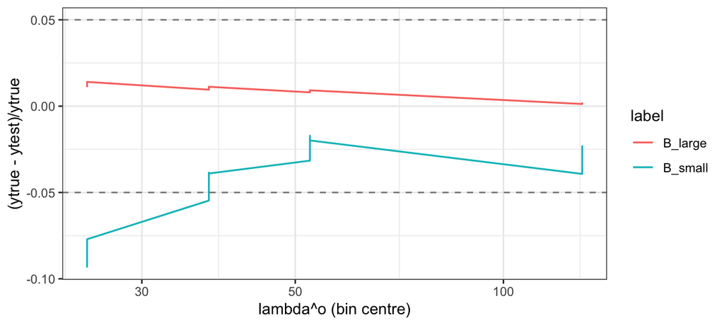

## 2.8 $b_{\rm sel,marg}(\theta)$ closure — `bsel`

**Retired with the theta table.** The current `b_sel_marg` + `bsel` pair no longer publishes a `b_sel_marginalised/{theta, vals}` grid: the $\theta$ dependence factorizes exactly in the C++ operators, so `bsel` publishes only the two plateau scalars `b_sel_marginalised/{b_small, b_large}` per wall row and every consumer (ShearPrjGl, ShearPrjCuhre) assembles $b_{\rm sel,marg}(\theta) = \overline{B_0}\,(1 - \sigma(\theta)) + \overline{B_\infty}\,\sigma(\theta)$ analytically in-integrand. The plateau amplitudes themselves are validated in the previous section; there is no longer a published $\theta$-grid to pin. (The historical audit-item-7 record below is kept for provenance.)

**Validation TSV not found — run `make data` after fresh `cosmosis cosmosis-models/physics_validation_pipelines.ini` and `cosmosis cosmosis-models/physics_validation_camb.ini` runs.**

## 2.9 $\Sigma^{1h}(R)$ — 1-halo lensing surface density

**Not emitted by the pipelines backend.** The des_y3 1-halo module `Shear1hGl` (`src/pipelines/des_y3/shear_1h2h/cpp/0d`) publishes the observable $\gamma_t^{1h}$ only — there is no pipelines producer of a standalone $\Sigma^{1h}$ wall (production `Sigma1hSel` is not part of the physics_validation pipeline). The 1-halo physics is covered by the $\gamma_t^{1h}$ section below and, at the profile-table level, by `test/halo_model.test.py` / `test/shear1h_gl.test.cc`.

**Validation TSV not found — run `make data` after fresh `cosmosis cosmosis-models/physics_validation_pipelines.ini` and `cosmosis cosmosis-models/physics_validation_camb.ini` runs.**

## 2.10 $\Delta\Sigma^{1h}(R)$ — 1-halo $\Delta\Sigma$

**Not emitted by the pipelines backend** — same status as the $\Sigma^{1h}$ section above (`Shear1hGl` publishes $\gamma_t^{1h}$ only).

**Validation TSV not found — run `make data` after fresh `cosmosis cosmosis-models/physics_validation_pipelines.ini` and `cosmosis cosmosis-models/physics_validation_camb.ini` runs.**

## 2.11 $\gamma_t^{1h}(R)$ — 1-halo tangential shear

CAMB-driven `Shear1hGl` (`ytrue`) vs cp_camb-driven `Shear1hGl` (`ytest`) — the fixed-GL des_y3 backend (`src/pipelines/des_y3/shear_1h2h/cpp/0d`, bitwise-identical algorithm to production `Shear1hMisSel`), with the DES-Y3 gamma-kernel miscentering mixture from the `[miscentering]` values. Tolerance 5% absorbs the noise floor at the largest-$R$ bin where $\gamma_t^{1h}$ is tiny (C++ rounding limit).

**120 of 120 points pass at frac < 0.05.**

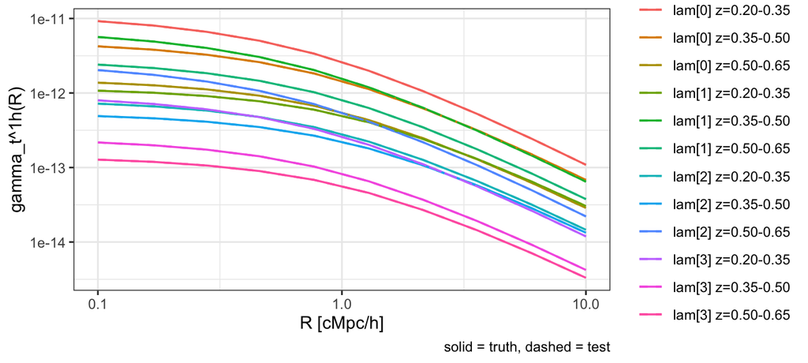

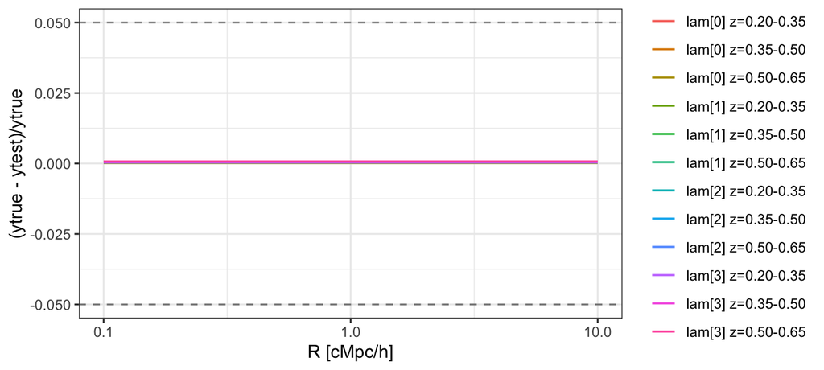

## 2.12 $\Sigma_{\rm prj}$ — two-halo projection

### 2.12.1 Pure-emulator check: `ShearPrjCuhre` (CAMB) vs (cp_camb)

CAMB-driven and cp_camb-driven `sigma_prj_cuhre` outputs (`ShearPrjCuhre`, `src/pipelines/des_y3/shear_projection/cpp/2d` — the only $\Sigma_{\rm prj}$ producer in the pipelines run; the fixed-GL `ShearPrjGl` publishes $\Delta\Sigma_{\rm prj}$ and $\gamma_t^{\rm prj}$ only). Same backend on both arms, only $P(k)$ differs. Headline: $\le 1.4\%$ over $R \in [0.1, 30]\,h^{-1}$ Mpc per `pipeline_modules.tex` §10.

**120 of 120 points pass at frac < 0.05.**

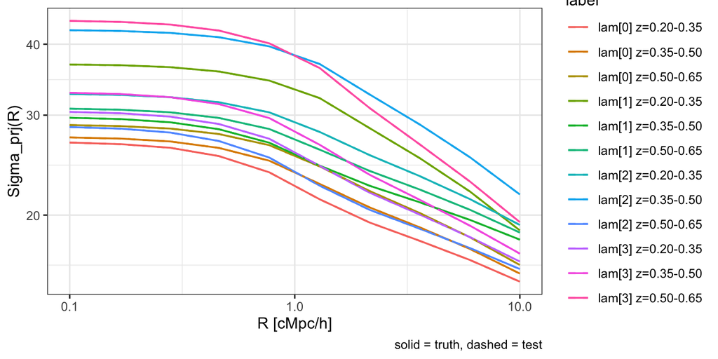

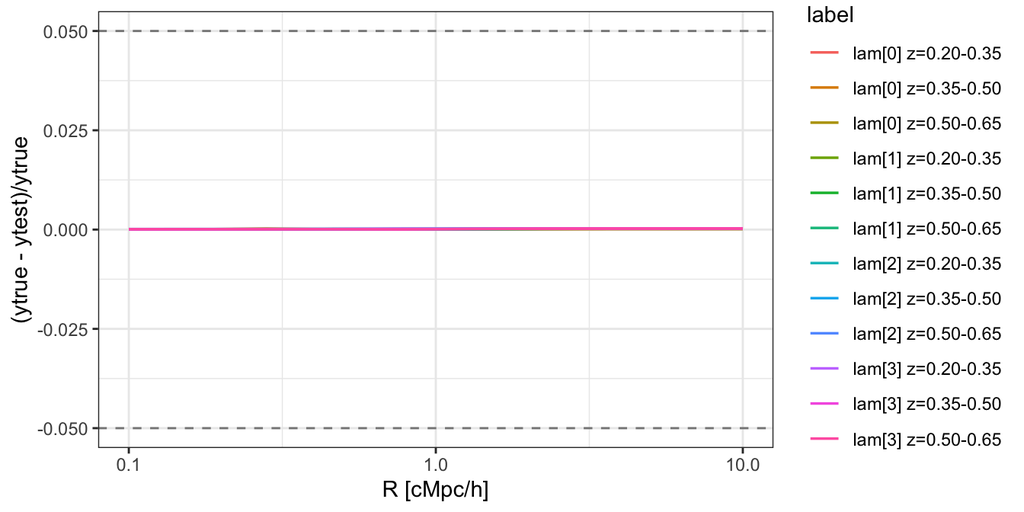

### 2.12.2 Integrator-precision check: `ShearPrjCuhre` (cp_camb) vs `ShearPrjGl` (cp_camb)

**Not available for $\Sigma_{\rm prj}$:** the fixed-GL `ShearPrjGl` does not publish a $\Sigma_{\rm prj}$ wall, so there is no evaluator to compare `sigma_prj_cuhre` against. The Cuhre-vs-GL check runs on the $\Delta\Sigma_{\rm prj}$ and $\gamma_t^{\rm prj}$ sections below — see the normalisation-drift flag there.

**Validation TSV not found — run `make data` after fresh `cosmosis cosmosis-models/physics_validation_pipelines.ini` and `cosmosis cosmosis-models/physics_validation_camb.ini` runs.**

## 2.13 $\Delta\Sigma_{\rm prj}$ — two-halo $\Delta\Sigma$

### 2.13.1 Pure-emulator check: `ShearPrjGl` (CAMB) vs (cp_camb)

CAMB-driven vs cp_camb-driven `dsigma_prj_gl` (`ShearPrjGl`, `src/pipelines/des_y3/shear_projection/cpp/0d` — same `sp_detail::ShearPrjCore` as production `shear_prj_frozen_physics`). With the CAMB companion pinned to linear $\xi_{\rm NL}$ (issue #9 apples-to-apples, see the Part I preamble) the residual is the pure emulator effect: **median 0.02%, max 0.07%** on this run pair.

**120 of 120 points pass at frac < 0.05.**

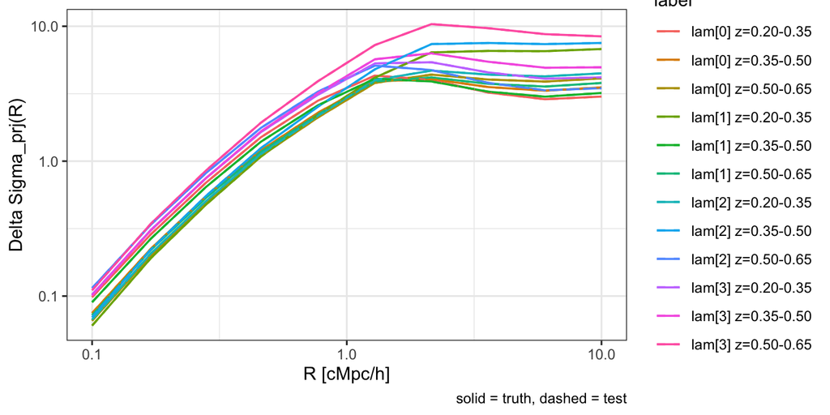

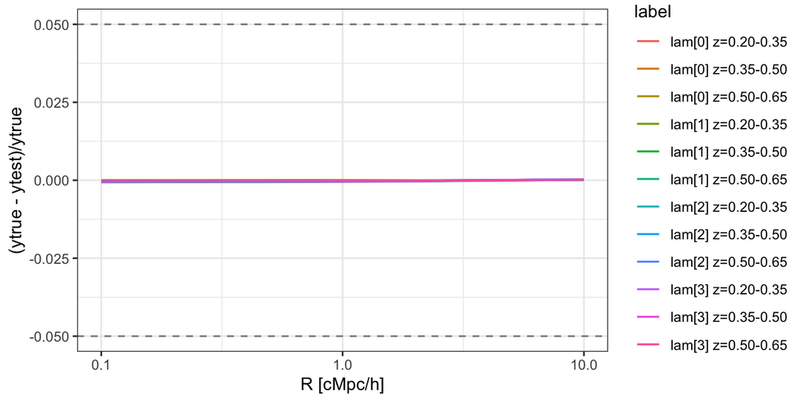

### 2.13.2 Integrator-precision check: `ShearPrjCuhre` vs `ShearPrjGl` (cp_camb)

> **🚨 FLAGGED — `ShearPrjCuhre` normalisation drift (issue #23, backend status “pending” in `src/pipelines/des_y3/shear_projection/README.md`).** The Cuhre adaptive backend and the fixed-GL `ShearPrjGl` should agree to the Cuhre tolerance ($\sim 10^{-3}$) on the same datablock. They instead disagree by a flat factor $\approx 0.46$ (GL $\approx 2.15 \times$ Cuhre) across **all** 120 cells (median $|\Delta|/{\rm GL} \approx 1.17$), `cl` and `rnd` scaled equally — a multiplicative normalisation on the Cuhre code path, unchanged from the pre-pipelines smoke runs. Treat as a known offset until the 2d backend’s pending re-validation lands.

**0 of 120 points pass at frac < 0.05.**

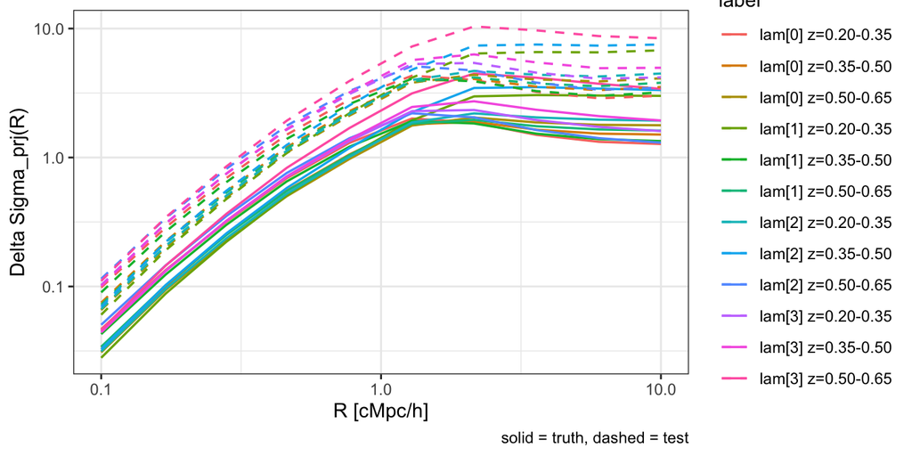

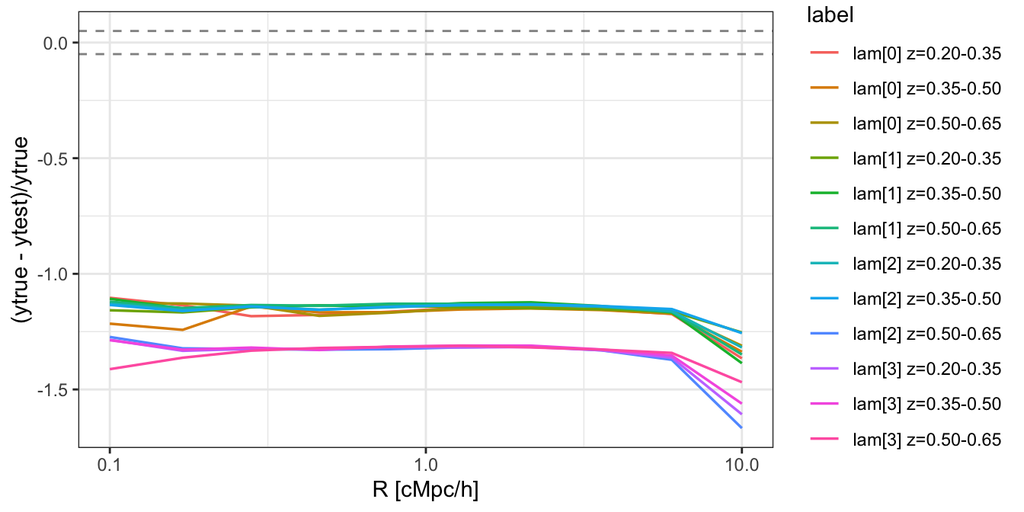

## 2.14 $\gamma_t^{\rm prj}$ — two-halo tangential shear

### 2.14.1 Pure-emulator check: `ShearPrjGl` (CAMB) vs (cp_camb)

**120 of 120 points pass at frac < 0.05.**

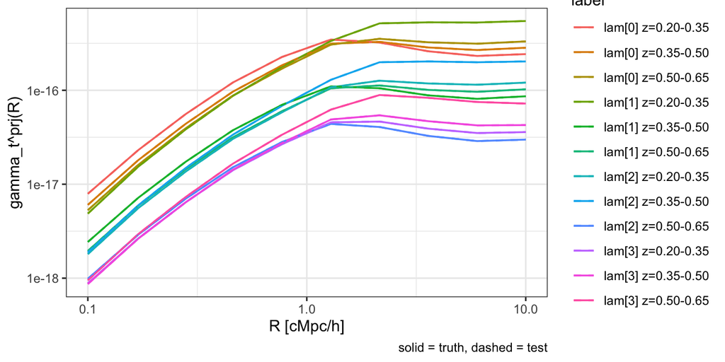

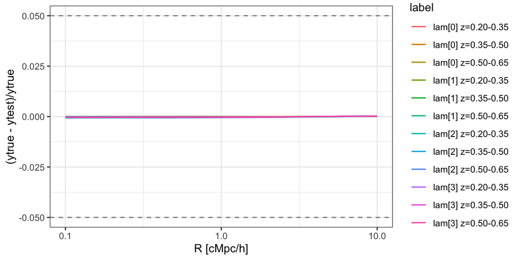

### 2.14.2 Integrator-precision check: `ShearPrjCuhre` vs `ShearPrjGl` (cp_camb)

Inherits the same $\approx 0.46$ normalisation offset flagged in the $\Delta\Sigma_{\rm prj}$ Cuhre subsection (issue #23).

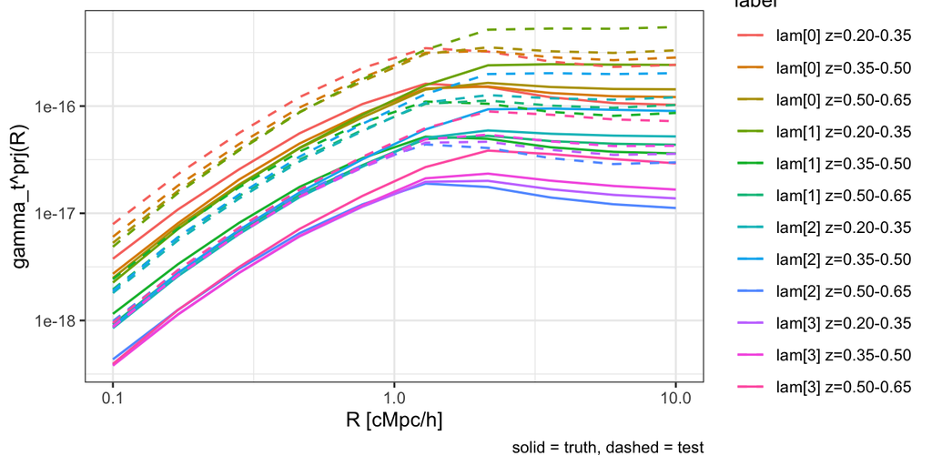

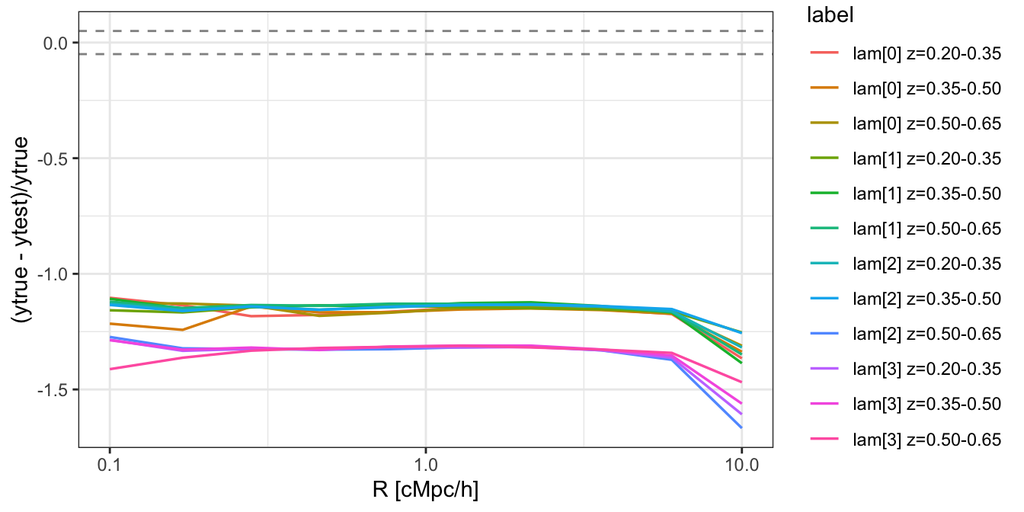

Pointer: `pipeline_modules.tex` §10 (line 742); the per-$R$ `rnd`/`cl` decomposition is in `docs/sigma_prj_py_vs_cpp_report.tex`.

## 2.15 Pipeline timing & precision audit

*audit_data.R not present in this checkout — see `docs/pipeline_modules.tex` §12 for the timing & precision audit.*

# 3 Part II — Per-term Y1 baseline (appendix)

The sections below validate the *underlying terms* used inside the Costanzi-2026 operators (`mor_t2`, `lc_lt_t`, `lo_lc_t`, `sigma_crit_inverse_t`, etc.). They are kept as the term-level regression suite — Part I is the headline end-to-end view.

## 3.1 Survey Area

### 3.1.1 SDSS Survey footprint function

$\Omega_z$ is the area of the survey as a function of redshift $z$. This section tests our implementation of the SDSS survey area function, which is implemented in the file `omega_z_sdss.hh`.

For this testing, we compare our function output to the independent function evaluations from Matteo Costanzi in the SDSS cluster cosmology analysis (Costanzi et al. 2019).

1. The comparisons are done at 550 unique $z$ points.
2. Over the range tested $(0.05 < z < 0.598)$, the maximum magnitude of the absolute residual between the expected value and our approximation is $6.0902368\times 10^{-7}$; the maximum magnitude of the fractional residual is $1.9964541\times 10^{-7}$.
3. For this test, we require the relative residuals to be less than $10^{-6}$, or the absolute residuals to be less than $10^{-12}$.
4. **For this test, 550 of 550 points pass.**

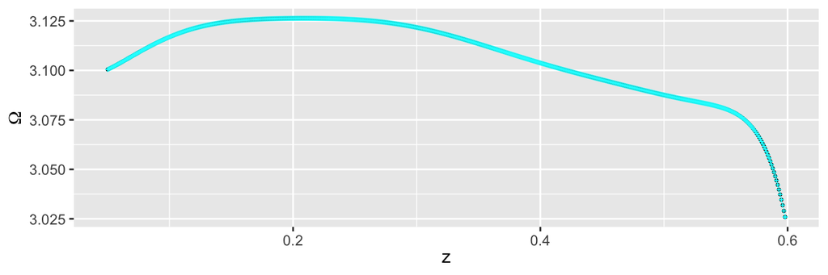

Absolute comparison of our implementation results (cyan points) to the expected values (black points) for $\Omega_z$. Note that over-plotting may obscure the expected values.

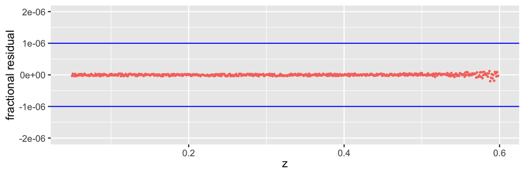

Relative residual between our implementation results and the expected values. Blue horizontal lines are the error tolerance bounds. Blue points pass, and red points fail, the absolute residual test.

## 3.2 Halo Mass Function

$n(M_{200m}, z)$ is the halo mass function, which describes the 3D cosmic density of halos at a given mass $M_{200m}$ and $z$. We have modified the CosmoSIS halo mass function module to consider the effect of massive neutrinos (Costanzi et al. 2013)- we use the $P_{cdm}$ power spectrum rather than the $P_{tot}$.

For this testing, we compare results from our implementation to the independent function evaluations from Matteo Costanzi in the SDSS cluster cosmology analysis (Costanzi et al. 2019)

Each panel in the figure below corresponds to a different $z$ value, specified in the panel top label.

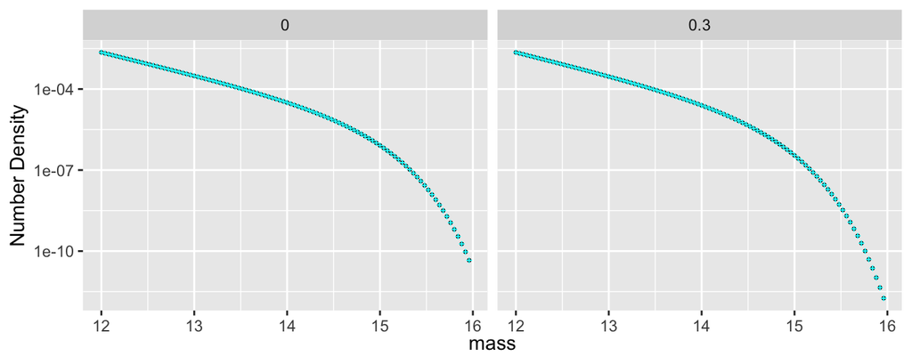

Absolute comparison of our implementation to the expected results. Note that over-plotting may obscure the expected values, if the approximated values are very close.

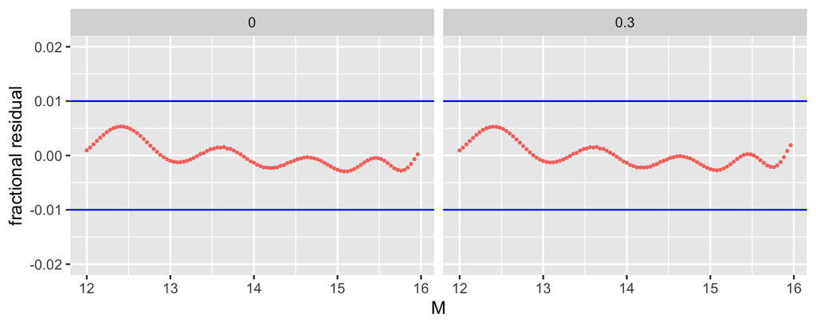

Relative residual comparison of our implementation to the expected results. Blue points pass, and red points fail, the absolute residual test.

**This test requires running masses_test.ini in cosmosis_tests first** Need to do better than this in the future.

## 3.3 Volume Element

$\frac{dV}{d\Omega dz}$ is the co-moving volume element in solid angle $d \Omega$ and redshift interval $dz$, and is a function of $z$. Our implementation is in the file `dv_do_dz_t.hh`.

For this testing, we compare our function output to the independent function evaluations from Matteo Costanzi in the SDSS cluster cosmology analysis (Costanzi et al. 2019), calculated with $\Omega_m =0.3$, $\Omega_\Lambda =0.7$, $h_0=0.7$.

1. The comparisons are done at 100 unique $z$ values.
2. Over the range tested $(0.01 < z < 0.99)$, the maximum magnitude of the absolute residual between the expected value and our approximation is $2.150846\times 10^{6}$; the maximum magnitude of the fractional residual is $2.3831532\times 10^{-4}$.
3. For this test, we require the relative residuals to be less than $0.001$, or the absolute residuals to be less than $10^{-12}$.
4. **For this test, 100 of 100 points pass.**

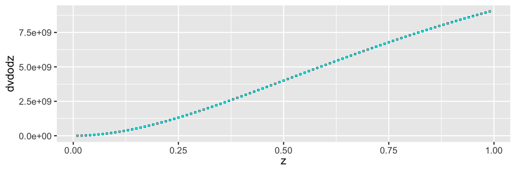

Absolute comparison of our approximation to the expected results. Note that over-plotting may obscure the expected values, if the approximated values are very close.

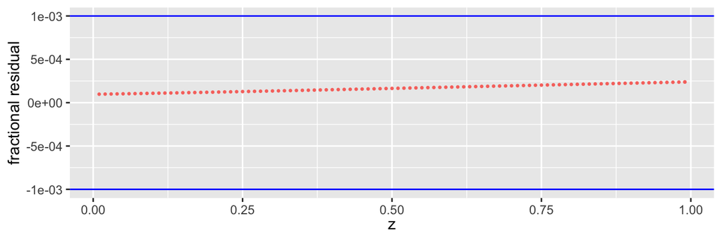

Relative residual comparison or implementation to the expected results. Points in blue pass, and points in red fail, the absolute residual test.